# examples_0528

Three people are buying fruit, and there are five grocery stores. Each person has a shopping list dictating how many pounds of each fruit to buy. Each store has different unit costs of fruit.

In order to consider the **total** cost for each person at each store, we can use [matrix multiplication](https://en.wikipedia.org/wiki/Matrix_multiplication). In order to help visualize matrix multiplication, the shopping lists are shown as a matrix on the bottom-left, the unit prices as a matrix on top-right, and the resulting matrix of totals in the bottom-right.

A peculiarity of matrix multiplication requires the **columns** of the first matrix to "match" the **rows** of the second matrix. In this case, notice the various fruits correspond to columns in the first matrix (bottom-left) and rows in the second matrix (top-right). This visualization is an attempt to make this seem more natural.

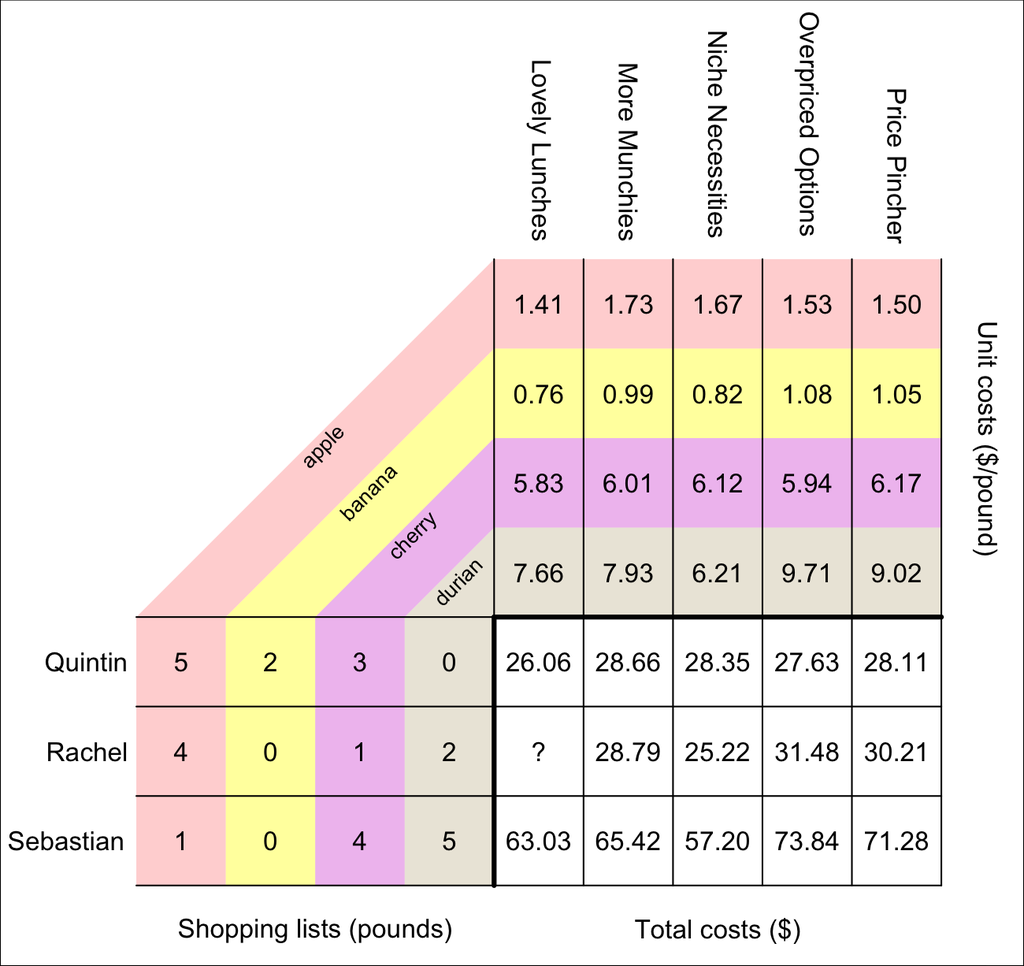

What is the total cost of Rachel shopping at Lovely Lunches?

Rachel wishes to buy 4 lb of apple, 0 lb of banana, 1 lb of cherry, and 2 lb of durian. At Lovely Lunches, the unit price of apple is $1.41/lb, the unit price of banana is $0.76/lb, the unit price of cherry is $5.83/lb, and the unit price of durian is $7.66/lb.

To find the total cost of Rachel's shopping trip, multiply each quantity by its corresponding unit price and then add up all those products.

$$(4\cdot1.41)~+~(0\cdot0.76)~+~(1\cdot5.83)~+~(2\cdot7.66)$$
$$5.64~+~0~+~5.83~+~15.32$$
$$26.79$$

So, the total cost of Rachel shopping at Lovely Lunches is $26.79.

In standard math notation, the matrix multiplication would be shown as:

$$\begin{bmatrix}
5 & 2 & 3 & 0\\
4 & 0 & 1 & 2\\
1 & 0 & 4 & 5
\end{bmatrix} \cdot \begin{bmatrix}
1.41 & 1.73 & 1.67 & 1.53 & 1.5\\
0.76 & 0.99 & 0.82 & 1.08 & 1.05\\
5.83 & 6.01 & 6.12 & 5.94 & 6.17\\
7.66 & 7.93 & 6.21 & 9.71 & 9.02
\end{bmatrix} ~=~ \begin{bmatrix}
26.06 & 28.66 & 28.35 & 27.63 & 28.11\\
26.79 & 28.79 & 25.22 & 31.48 & 30.21\\
63.03 & 65.42 & 57.2 & 73.84 & 71.28
\end{bmatrix}$$

Three people are buying fruit, and there are five grocery stores. Each person has a shopping list dictating how many pounds of each fruit to buy. Each store has different unit costs of fruit.

In order to consider the **total** cost for each person at each store, we can use [matrix multiplication](https://en.wikipedia.org/wiki/Matrix_multiplication). In order to help visualize matrix multiplication, the shopping lists are shown as a matrix on the bottom-left, the unit prices as a matrix on top-right, and the resulting matrix of totals in the bottom-right.

A peculiarity of matrix multiplication requires the **columns** of the first matrix to "match" the **rows** of the second matrix. In this case, notice the various fruits correspond to columns in the first matrix (bottom-left) and rows in the second matrix (top-right). This visualization is an attempt to make this seem more natural.

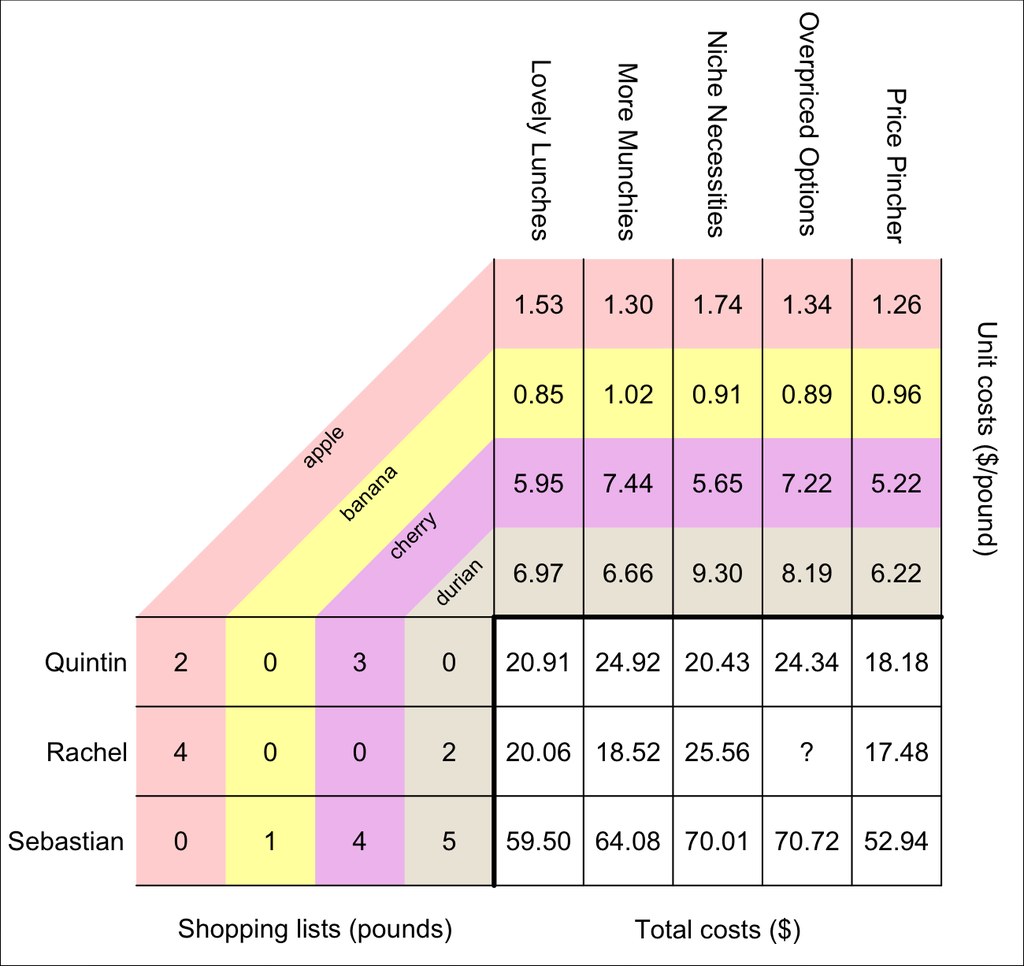

What is the total cost of Rachel shopping at Overpriced Options?

Rachel wishes to buy 4 lb of apple, 0 lb of banana, 0 lb of cherry, and 2 lb of durian. At Overpriced Options, the unit price of apple is $1.34/lb, the unit price of banana is $0.89/lb, the unit price of cherry is $7.22/lb, and the unit price of durian is $8.19/lb.

To find the total cost of Rachel's shopping trip, multiply each quantity by its corresponding unit price and then add up all those products.

$$(4\cdot1.34)~+~(0\cdot0.89)~+~(0\cdot7.22)~+~(2\cdot8.19)$$
$$5.36~+~0~+~0~+~16.38$$
$$21.74$$

So, the total cost of Rachel shopping at Overpriced Options is $21.74.

In standard math notation, the matrix multiplication would be shown as:

$$\begin{bmatrix}
2 & 0 & 3 & 0\\
4 & 0 & 0 & 2\\
0 & 1 & 4 & 5
\end{bmatrix} \cdot \begin{bmatrix}
1.53 & 1.3 & 1.74 & 1.34 & 1.26\\
0.85 & 1.02 & 0.91 & 0.89 & 0.96\\
5.95 & 7.44 & 5.65 & 7.22 & 5.22\\
6.97 & 6.66 & 9.3 & 8.19 & 6.22
\end{bmatrix} ~=~ \begin{bmatrix}
20.91 & 24.92 & 20.43 & 24.34 & 18.18\\
20.06 & 18.52 & 25.56 & 21.74 & 17.48\\
59.5 & 64.08 & 70.01 & 70.72 & 52.94
\end{bmatrix}$$

Three people are buying fruit, and there are five grocery stores. Each person has a shopping list dictating how many pounds of each fruit to buy. Each store has different unit costs of fruit.

In order to consider the **total** cost for each person at each store, we can use [matrix multiplication](https://en.wikipedia.org/wiki/Matrix_multiplication). In order to help visualize matrix multiplication, the shopping lists are shown as a matrix on the bottom-left, the unit prices as a matrix on top-right, and the resulting matrix of totals in the bottom-right.

A peculiarity of matrix multiplication requires the **columns** of the first matrix to "match" the **rows** of the second matrix. In this case, notice the various fruits correspond to columns in the first matrix (bottom-left) and rows in the second matrix (top-right). This visualization is an attempt to make this seem more natural.

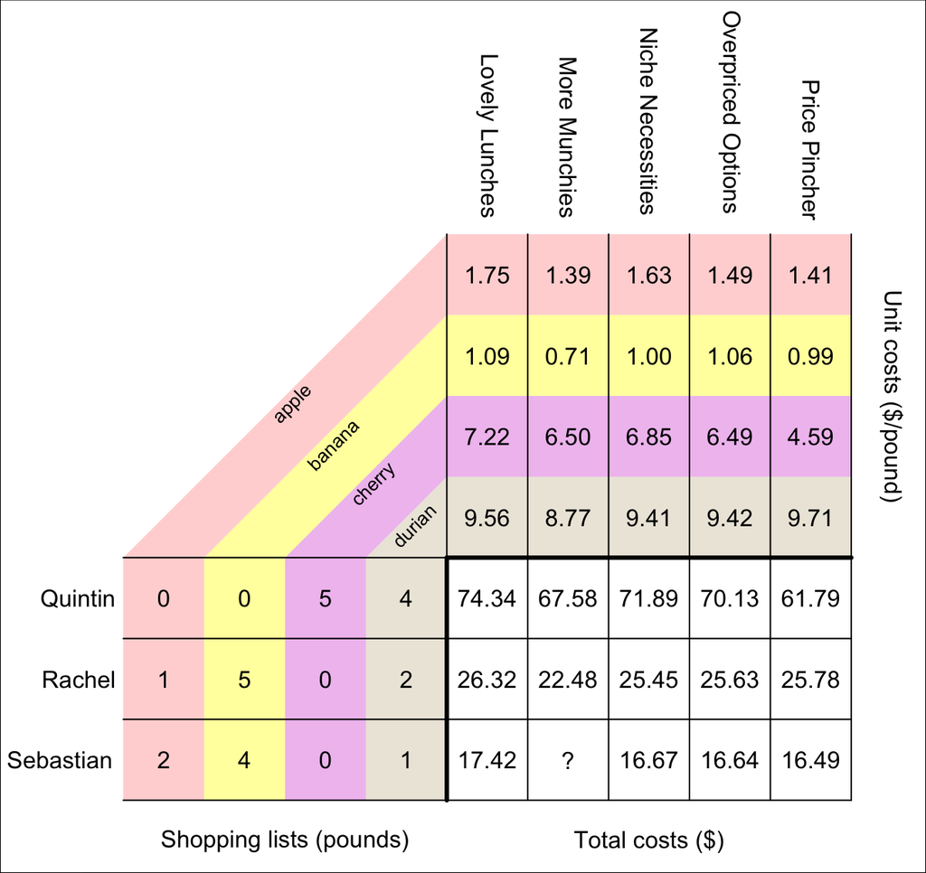

What is the total cost of Sebastian shopping at More Munchies?

Sebastian wishes to buy 2 lb of apple, 4 lb of banana, 0 lb of cherry, and 1 lb of durian. At More Munchies, the unit price of apple is $1.39/lb, the unit price of banana is $0.71/lb, the unit price of cherry is $6.50/lb, and the unit price of durian is $8.77/lb.

To find the total cost of Sebastian's shopping trip, multiply each quantity by its corresponding unit price and then add up all those products.

$$(2\cdot1.39)~+~(4\cdot0.71)~+~(0\cdot6.5)~+~(1\cdot8.77)$$
$$2.78~+~2.84~+~0~+~8.77$$
$$14.39$$

So, the total cost of Sebastian shopping at More Munchies is $14.39.

In standard math notation, the matrix multiplication would be shown as:

$$\begin{bmatrix}
0 & 0 & 5 & 4\\
1 & 5 & 0 & 2\\
2 & 4 & 0 & 1
\end{bmatrix} \cdot \begin{bmatrix}
1.75 & 1.39 & 1.63 & 1.49 & 1.41\\
1.09 & 0.71 & 1 & 1.06 & 0.99\\
7.22 & 6.5 & 6.85 & 6.49 & 4.59\\
9.56 & 8.77 & 9.41 & 9.42 & 9.71
\end{bmatrix} ~=~ \begin{bmatrix}
74.34 & 67.58 & 71.89 & 70.13 & 61.79\\
26.32 & 22.48 & 25.45 & 25.63 & 25.78\\
17.42 & 14.39 & 16.67 & 16.64 & 16.49
\end{bmatrix}$$

Three people are buying fruit, and there are five grocery stores. Each person has a shopping list dictating how many pounds of each fruit to buy. Each store has different unit costs of fruit.

In order to consider the **total** cost for each person at each store, we can use [matrix multiplication](https://en.wikipedia.org/wiki/Matrix_multiplication). In order to help visualize matrix multiplication, the shopping lists are shown as a matrix on the bottom-left, the unit prices as a matrix on top-right, and the resulting matrix of totals in the bottom-right.

A peculiarity of matrix multiplication requires the **columns** of the first matrix to "match" the **rows** of the second matrix. In this case, notice the various fruits correspond to columns in the first matrix (bottom-left) and rows in the second matrix (top-right). This visualization is an attempt to make this seem more natural.

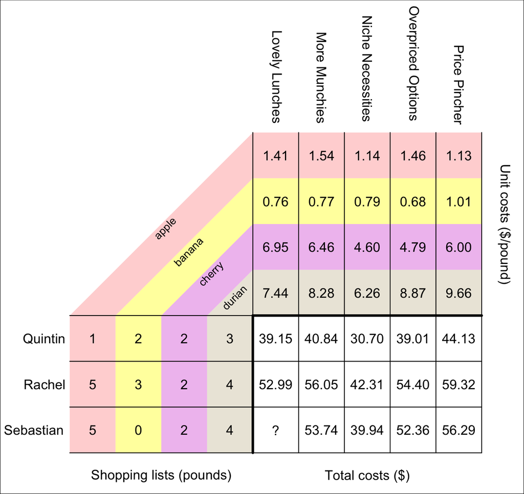

What is the total cost of Sebastian shopping at Lovely Lunches?

Sebastian wishes to buy 5 lb of apple, 0 lb of banana, 2 lb of cherry, and 4 lb of durian. At Lovely Lunches, the unit price of apple is $1.41/lb, the unit price of banana is $0.76/lb, the unit price of cherry is $6.95/lb, and the unit price of durian is $7.44/lb.

To find the total cost of Sebastian's shopping trip, multiply each quantity by its corresponding unit price and then add up all those products.

$$(5\cdot1.41)~+~(0\cdot0.76)~+~(2\cdot6.95)~+~(4\cdot7.44)$$
$$7.05~+~0~+~13.9~+~29.76$$
$$50.71$$

So, the total cost of Sebastian shopping at Lovely Lunches is $50.71.

In standard math notation, the matrix multiplication would be shown as:

$$\begin{bmatrix}
1 & 2 & 2 & 3\\
5 & 3 & 2 & 4\\
5 & 0 & 2 & 4
\end{bmatrix} \cdot \begin{bmatrix}
1.41 & 1.54 & 1.14 & 1.46 & 1.13\\
0.76 & 0.77 & 0.79 & 0.68 & 1.01\\
6.95 & 6.46 & 4.6 & 4.79 & 6\\
7.44 & 8.28 & 6.26 & 8.87 & 9.66
\end{bmatrix} ~=~ \begin{bmatrix}
39.15 & 40.84 & 30.7 & 39.01 & 44.13\\
52.99 & 56.05 & 42.31 & 54.4 & 59.32\\
50.71 & 53.74 & 39.94 & 52.36 & 56.29
\end{bmatrix}$$

Three people are buying fruit, and there are five grocery stores. Each person has a shopping list dictating how many pounds of each fruit to buy. Each store has different unit costs of fruit.

In order to consider the **total** cost for each person at each store, we can use [matrix multiplication](https://en.wikipedia.org/wiki/Matrix_multiplication). In order to help visualize matrix multiplication, the shopping lists are shown as a matrix on the bottom-left, the unit prices as a matrix on top-right, and the resulting matrix of totals in the bottom-right.

A peculiarity of matrix multiplication requires the **columns** of the first matrix to "match" the **rows** of the second matrix. In this case, notice the various fruits correspond to columns in the first matrix (bottom-left) and rows in the second matrix (top-right). This visualization is an attempt to make this seem more natural.

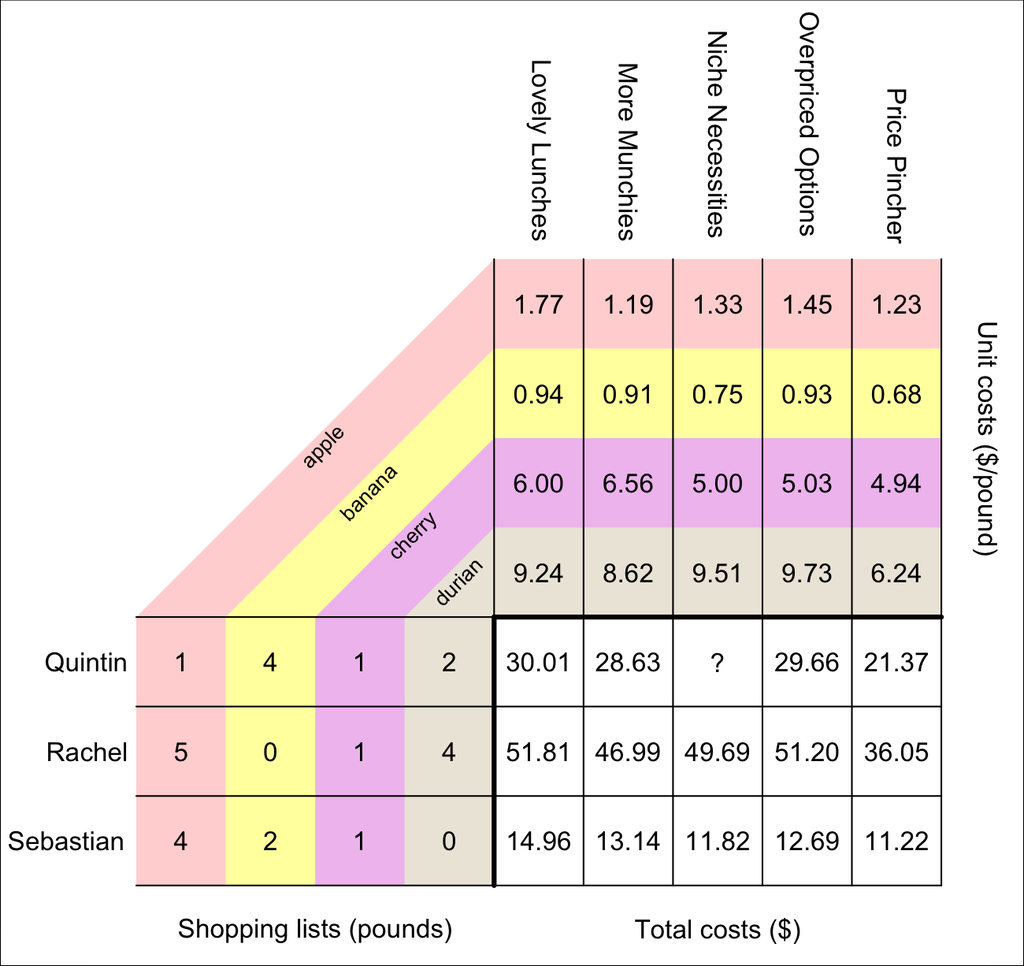

What is the total cost of Quintin shopping at Niche Necessities?

Quintin wishes to buy 1 lb of apple, 4 lb of banana, 1 lb of cherry, and 2 lb of durian. At Niche Necessities, the unit price of apple is $1.33/lb, the unit price of banana is $0.75/lb, the unit price of cherry is $5.00/lb, and the unit price of durian is $9.51/lb.

To find the total cost of Quintin's shopping trip, multiply each quantity by its corresponding unit price and then add up all those products.

$$(1\cdot1.33)~+~(4\cdot0.75)~+~(1\cdot5)~+~(2\cdot9.51)$$
$$1.33~+~3~+~5~+~19.02$$
$$28.35$$

So, the total cost of Quintin shopping at Niche Necessities is $28.35.

In standard math notation, the matrix multiplication would be shown as:

$$\begin{bmatrix}
1 & 4 & 1 & 2\\
5 & 0 & 1 & 4\\
4 & 2 & 1 & 0
\end{bmatrix} \cdot \begin{bmatrix}
1.77 & 1.19 & 1.33 & 1.45 & 1.23\\
0.94 & 0.91 & 0.75 & 0.93 & 0.68\\
6 & 6.56 & 5 & 5.03 & 4.94\\
9.24 & 8.62 & 9.51 & 9.73 & 6.24
\end{bmatrix} ~=~ \begin{bmatrix}
30.01 & 28.63 & 28.35 & 29.66 & 21.37\\
51.81 & 46.99 & 49.69 & 51.2 & 36.05\\
14.96 & 13.14 & 11.82 & 12.69 & 11.22
\end{bmatrix}$$

Three people are buying fruit, and there are five grocery stores. Each person has a shopping list dictating how many pounds of each fruit to buy. Each store has different unit costs of fruit.

In order to consider the **total** cost for each person at each store, we can use [matrix multiplication](https://en.wikipedia.org/wiki/Matrix_multiplication). In order to help visualize matrix multiplication, the shopping lists are shown as a matrix on the bottom-left, the unit prices as a matrix on top-right, and the resulting matrix of totals in the bottom-right.

A peculiarity of matrix multiplication requires the **columns** of the first matrix to "match" the **rows** of the second matrix. In this case, notice the various fruits correspond to columns in the first matrix (bottom-left) and rows in the second matrix (top-right). This visualization is an attempt to make this seem more natural.

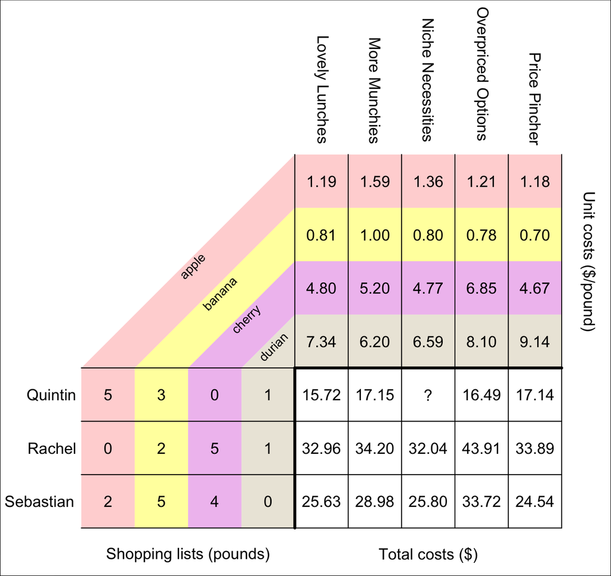

What is the total cost of Quintin shopping at Niche Necessities?

Quintin wishes to buy 5 lb of apple, 3 lb of banana, 0 lb of cherry, and 1 lb of durian. At Niche Necessities, the unit price of apple is $1.36/lb, the unit price of banana is $0.80/lb, the unit price of cherry is $4.77/lb, and the unit price of durian is $6.59/lb.

To find the total cost of Quintin's shopping trip, multiply each quantity by its corresponding unit price and then add up all those products.

$$(5\cdot1.36)~+~(3\cdot0.8)~+~(0\cdot4.77)~+~(1\cdot6.59)$$
$$6.8~+~2.4~+~0~+~6.59$$
$$15.79$$

So, the total cost of Quintin shopping at Niche Necessities is $15.79.

In standard math notation, the matrix multiplication would be shown as:

$$\begin{bmatrix}
5 & 3 & 0 & 1\\
0 & 2 & 5 & 1\\
2 & 5 & 4 & 0
\end{bmatrix} \cdot \begin{bmatrix}
1.19 & 1.59 & 1.36 & 1.21 & 1.18\\
0.81 & 1 & 0.8 & 0.78 & 0.7\\
4.8 & 5.2 & 4.77 & 6.85 & 4.67\\
7.34 & 6.2 & 6.59 & 8.1 & 9.14
\end{bmatrix} ~=~ \begin{bmatrix}
15.72 & 17.15 & 15.79 & 16.49 & 17.14\\
32.96 & 34.2 & 32.04 & 43.91 & 33.89\\
25.63 & 28.98 & 25.8 & 33.72 & 24.54
\end{bmatrix}$$

Three people are buying fruit, and there are five grocery stores. Each person has a shopping list dictating how many pounds of each fruit to buy. Each store has different unit costs of fruit.

In order to consider the **total** cost for each person at each store, we can use [matrix multiplication](https://en.wikipedia.org/wiki/Matrix_multiplication). In order to help visualize matrix multiplication, the shopping lists are shown as a matrix on the bottom-left, the unit prices as a matrix on top-right, and the resulting matrix of totals in the bottom-right.

A peculiarity of matrix multiplication requires the **columns** of the first matrix to "match" the **rows** of the second matrix. In this case, notice the various fruits correspond to columns in the first matrix (bottom-left) and rows in the second matrix (top-right). This visualization is an attempt to make this seem more natural.

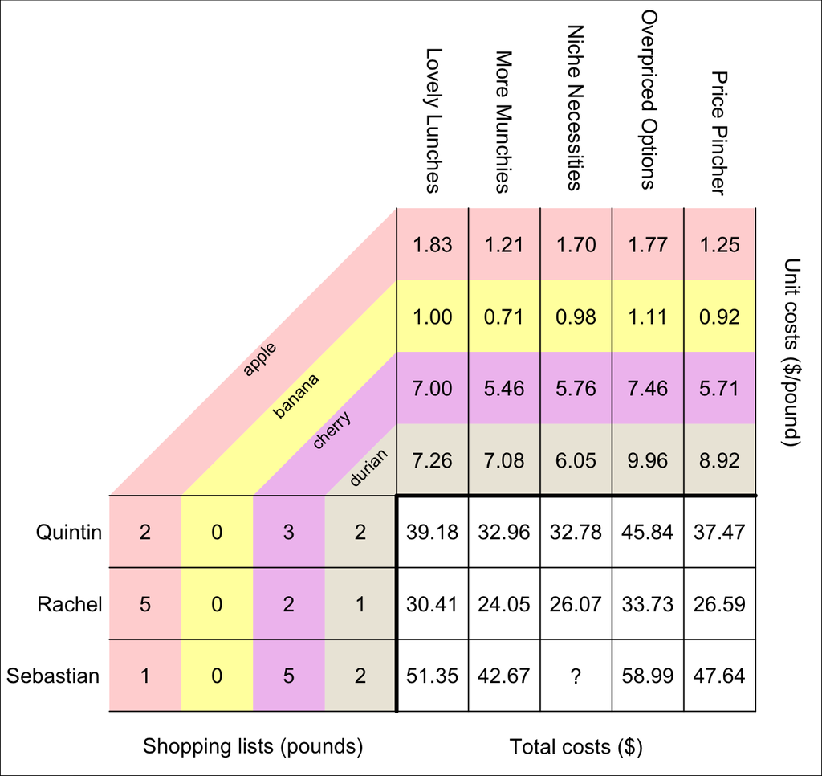

What is the total cost of Sebastian shopping at Niche Necessities?

Sebastian wishes to buy 1 lb of apple, 0 lb of banana, 5 lb of cherry, and 2 lb of durian. At Niche Necessities, the unit price of apple is $1.70/lb, the unit price of banana is $0.98/lb, the unit price of cherry is $5.76/lb, and the unit price of durian is $6.05/lb.

To find the total cost of Sebastian's shopping trip, multiply each quantity by its corresponding unit price and then add up all those products.

$$(1\cdot1.7)~+~(0\cdot0.98)~+~(5\cdot5.76)~+~(2\cdot6.05)$$
$$1.7~+~0~+~28.8~+~12.1$$
$$42.60$$

So, the total cost of Sebastian shopping at Niche Necessities is $42.60.

In standard math notation, the matrix multiplication would be shown as:

$$\begin{bmatrix}
2 & 0 & 3 & 2\\
5 & 0 & 2 & 1\\
1 & 0 & 5 & 2
\end{bmatrix} \cdot \begin{bmatrix}
1.83 & 1.21 & 1.7 & 1.77 & 1.25\\
1 & 0.71 & 0.98 & 1.11 & 0.92\\
7 & 5.46 & 5.76 & 7.46 & 5.71\\
7.26 & 7.08 & 6.05 & 9.96 & 8.92
\end{bmatrix} ~=~ \begin{bmatrix}
39.18 & 32.96 & 32.78 & 45.84 & 37.47\\
30.41 & 24.05 & 26.07 & 33.73 & 26.59\\
51.35 & 42.67 & 42.6 & 58.99 & 47.64
\end{bmatrix}$$

Three people are buying fruit, and there are five grocery stores. Each person has a shopping list dictating how many pounds of each fruit to buy. Each store has different unit costs of fruit.

In order to consider the **total** cost for each person at each store, we can use [matrix multiplication](https://en.wikipedia.org/wiki/Matrix_multiplication). In order to help visualize matrix multiplication, the shopping lists are shown as a matrix on the bottom-left, the unit prices as a matrix on top-right, and the resulting matrix of totals in the bottom-right.

A peculiarity of matrix multiplication requires the **columns** of the first matrix to "match" the **rows** of the second matrix. In this case, notice the various fruits correspond to columns in the first matrix (bottom-left) and rows in the second matrix (top-right). This visualization is an attempt to make this seem more natural.

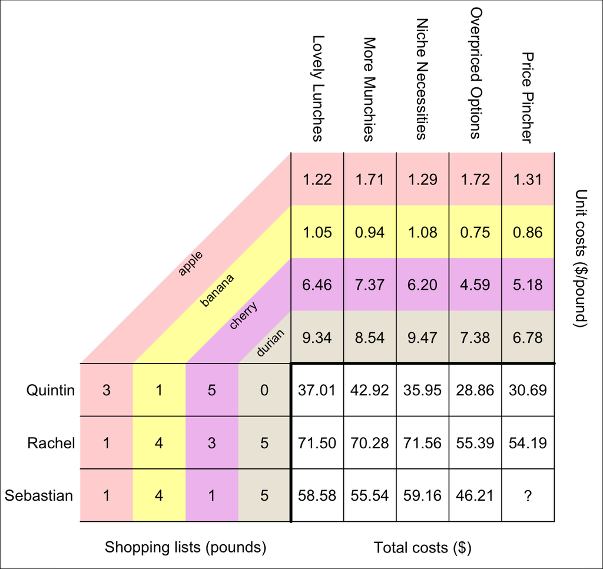

What is the total cost of Sebastian shopping at Price Pincher?

Sebastian wishes to buy 1 lb of apple, 4 lb of banana, 1 lb of cherry, and 5 lb of durian. At Price Pincher, the unit price of apple is $1.31/lb, the unit price of banana is $0.86/lb, the unit price of cherry is $5.18/lb, and the unit price of durian is $6.78/lb.

To find the total cost of Sebastian's shopping trip, multiply each quantity by its corresponding unit price and then add up all those products.

$$(1\cdot1.31)~+~(4\cdot0.86)~+~(1\cdot5.18)~+~(5\cdot6.78)$$
$$1.31~+~3.44~+~5.18~+~33.9$$
$$43.83$$

So, the total cost of Sebastian shopping at Price Pincher is $43.83.

In standard math notation, the matrix multiplication would be shown as:

$$\begin{bmatrix}
3 & 1 & 5 & 0\\
1 & 4 & 3 & 5\\
1 & 4 & 1 & 5
\end{bmatrix} \cdot \begin{bmatrix}
1.22 & 1.71 & 1.29 & 1.72 & 1.31\\
1.05 & 0.94 & 1.08 & 0.75 & 0.86\\
6.46 & 7.37 & 6.2 & 4.59 & 5.18\\
9.34 & 8.54 & 9.47 & 7.38 & 6.78
\end{bmatrix} ~=~ \begin{bmatrix}
37.01 & 42.92 & 35.95 & 28.86 & 30.69\\
71.5 & 70.28 & 71.56 & 55.39 & 54.19\\
58.58 & 55.54 & 59.16 & 46.21 & 43.83
\end{bmatrix}$$

Three people are buying fruit, and there are five grocery stores. Each person has a shopping list dictating how many pounds of each fruit to buy. Each store has different unit costs of fruit.

In order to consider the **total** cost for each person at each store, we can use [matrix multiplication](https://en.wikipedia.org/wiki/Matrix_multiplication). In order to help visualize matrix multiplication, the shopping lists are shown as a matrix on the bottom-left, the unit prices as a matrix on top-right, and the resulting matrix of totals in the bottom-right.

A peculiarity of matrix multiplication requires the **columns** of the first matrix to "match" the **rows** of the second matrix. In this case, notice the various fruits correspond to columns in the first matrix (bottom-left) and rows in the second matrix (top-right). This visualization is an attempt to make this seem more natural.

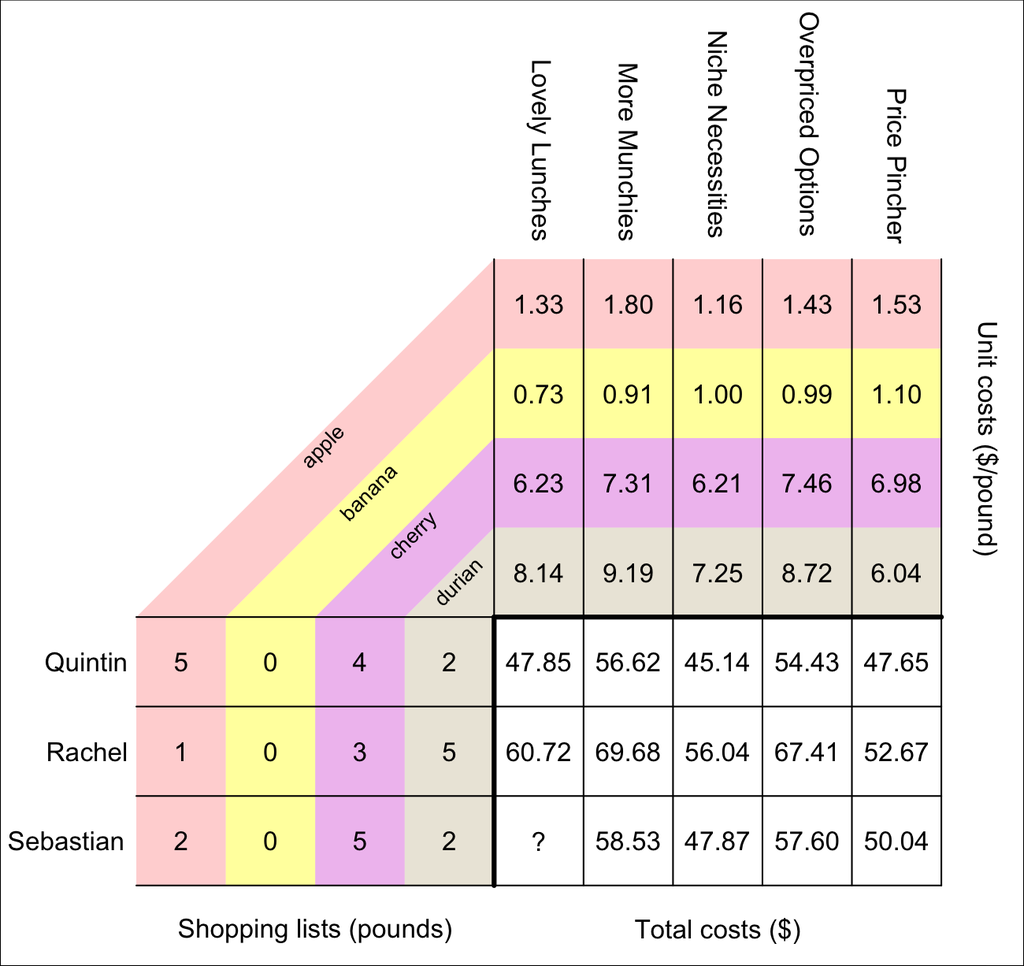

What is the total cost of Sebastian shopping at Lovely Lunches?

Sebastian wishes to buy 2 lb of apple, 0 lb of banana, 5 lb of cherry, and 2 lb of durian. At Lovely Lunches, the unit price of apple is $1.33/lb, the unit price of banana is $0.73/lb, the unit price of cherry is $6.23/lb, and the unit price of durian is $8.14/lb.

To find the total cost of Sebastian's shopping trip, multiply each quantity by its corresponding unit price and then add up all those products.

$$(2\cdot1.33)~+~(0\cdot0.73)~+~(5\cdot6.23)~+~(2\cdot8.14)$$
$$2.66~+~0~+~31.15~+~16.28$$
$$50.09$$

So, the total cost of Sebastian shopping at Lovely Lunches is $50.09.

In standard math notation, the matrix multiplication would be shown as:

$$\begin{bmatrix}
5 & 0 & 4 & 2\\
1 & 0 & 3 & 5\\
2 & 0 & 5 & 2
\end{bmatrix} \cdot \begin{bmatrix}
1.33 & 1.8 & 1.16 & 1.43 & 1.53\\
0.73 & 0.91 & 1 & 0.99 & 1.1\\
6.23 & 7.31 & 6.21 & 7.46 & 6.98\\
8.14 & 9.19 & 7.25 & 8.72 & 6.04
\end{bmatrix} ~=~ \begin{bmatrix}
47.85 & 56.62 & 45.14 & 54.43 & 47.65\\
60.72 & 69.68 & 56.04 & 67.41 & 52.67\\
50.09 & 58.53 & 47.87 & 57.6 & 50.04
\end{bmatrix}$$

Three people are buying fruit, and there are five grocery stores. Each person has a shopping list dictating how many pounds of each fruit to buy. Each store has different unit costs of fruit.

In order to consider the **total** cost for each person at each store, we can use [matrix multiplication](https://en.wikipedia.org/wiki/Matrix_multiplication). In order to help visualize matrix multiplication, the shopping lists are shown as a matrix on the bottom-left, the unit prices as a matrix on top-right, and the resulting matrix of totals in the bottom-right.

A peculiarity of matrix multiplication requires the **columns** of the first matrix to "match" the **rows** of the second matrix. In this case, notice the various fruits correspond to columns in the first matrix (bottom-left) and rows in the second matrix (top-right). This visualization is an attempt to make this seem more natural.

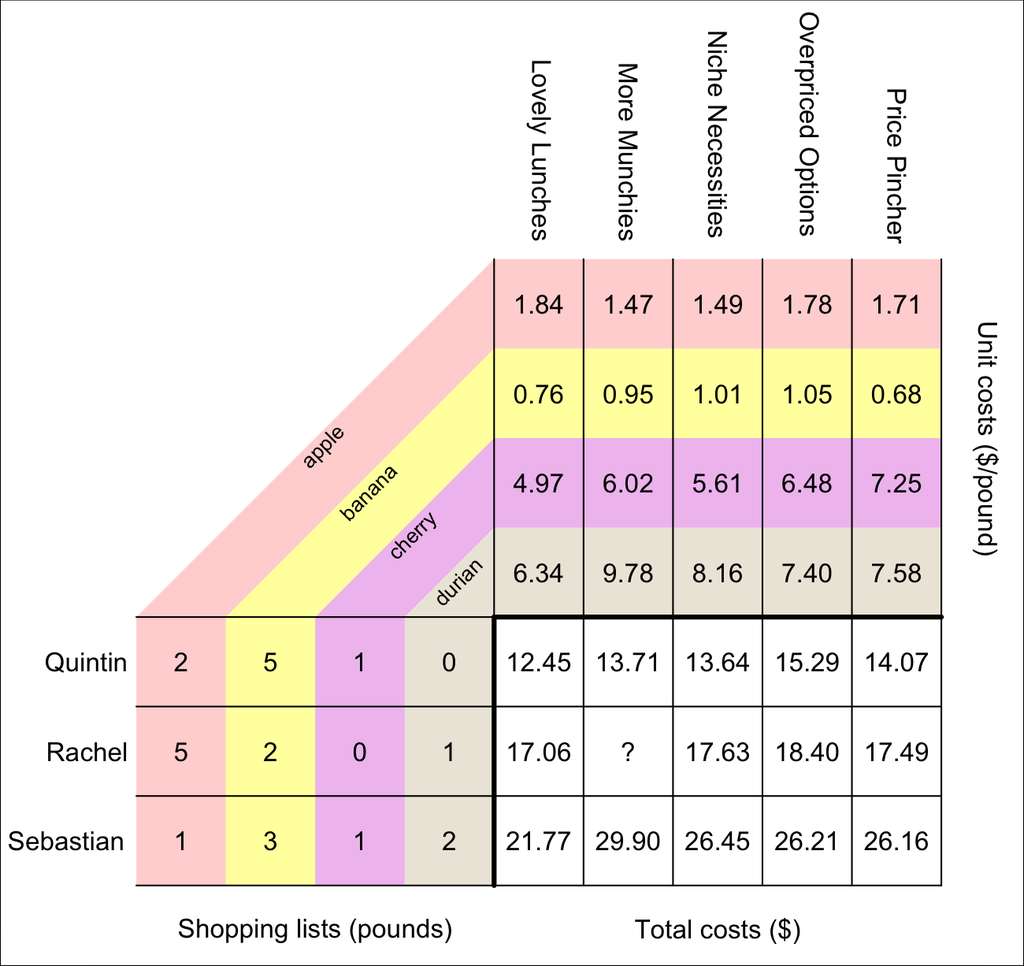

What is the total cost of Rachel shopping at More Munchies?

Rachel wishes to buy 5 lb of apple, 2 lb of banana, 0 lb of cherry, and 1 lb of durian. At More Munchies, the unit price of apple is $1.47/lb, the unit price of banana is $0.95/lb, the unit price of cherry is $6.02/lb, and the unit price of durian is $9.78/lb.

To find the total cost of Rachel's shopping trip, multiply each quantity by its corresponding unit price and then add up all those products.

$$(5\cdot1.47)~+~(2\cdot0.95)~+~(0\cdot6.02)~+~(1\cdot9.78)$$
$$7.35~+~1.9~+~0~+~9.78$$
$$19.03$$

So, the total cost of Rachel shopping at More Munchies is $19.03.

In standard math notation, the matrix multiplication would be shown as:

$$\begin{bmatrix}
2 & 5 & 1 & 0\\
5 & 2 & 0 & 1\\
1 & 3 & 1 & 2
\end{bmatrix} \cdot \begin{bmatrix}
1.84 & 1.47 & 1.49 & 1.78 & 1.71\\
0.76 & 0.95 & 1.01 & 1.05 & 0.68\\
4.97 & 6.02 & 5.61 & 6.48 & 7.25\\
6.34 & 9.78 & 8.16 & 7.4 & 7.58
\end{bmatrix} ~=~ \begin{bmatrix}
12.45 & 13.71 & 13.64 & 15.29 & 14.07\\
17.06 & 19.03 & 17.63 & 18.4 & 17.49\\
21.77 & 29.9 & 26.45 & 26.21 & 26.16
\end{bmatrix}$$

Three people are buying fruit, and there are five grocery stores. Each person has a shopping list dictating how many pounds of each fruit to buy. Each store has different unit costs of fruit.

In order to consider the **total** cost for each person at each store, we can use [matrix multiplication](https://en.wikipedia.org/wiki/Matrix_multiplication). In order to help visualize matrix multiplication, the shopping lists are shown as a matrix on the bottom-left, the unit prices as a matrix on top-right, and the resulting matrix of totals in the bottom-right.

A peculiarity of matrix multiplication requires the **columns** of the first matrix to "match" the **rows** of the second matrix. In this case, notice the various fruits correspond to columns in the first matrix (bottom-left) and rows in the second matrix (top-right). This visualization is an attempt to make this seem more natural.

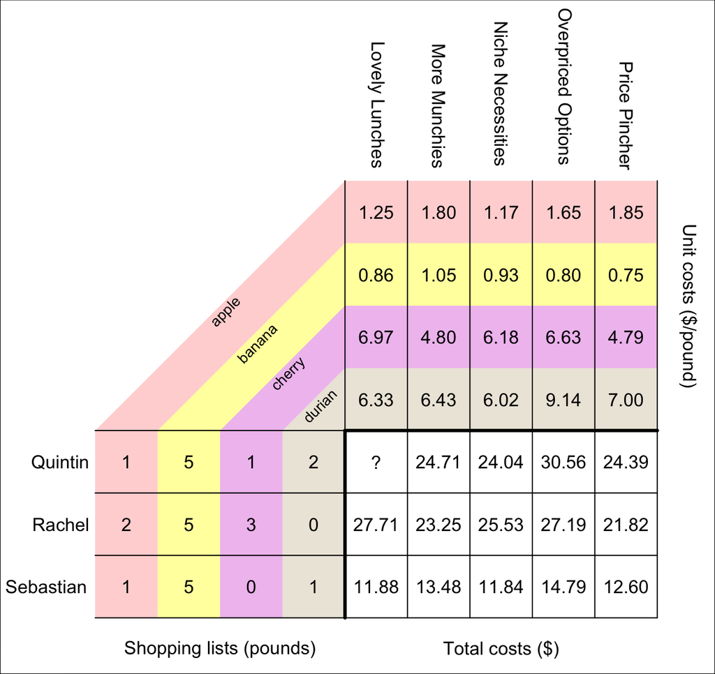

What is the total cost of Quintin shopping at Lovely Lunches?

Quintin wishes to buy 1 lb of apple, 5 lb of banana, 1 lb of cherry, and 2 lb of durian. At Lovely Lunches, the unit price of apple is $1.25/lb, the unit price of banana is $0.86/lb, the unit price of cherry is $6.97/lb, and the unit price of durian is $6.33/lb.

To find the total cost of Quintin's shopping trip, multiply each quantity by its corresponding unit price and then add up all those products.

$$(1\cdot1.25)~+~(5\cdot0.86)~+~(1\cdot6.97)~+~(2\cdot6.33)$$
$$1.25~+~4.3~+~6.97~+~12.66$$
$$25.18$$

So, the total cost of Quintin shopping at Lovely Lunches is $25.18.

In standard math notation, the matrix multiplication would be shown as:

$$\begin{bmatrix}
1 & 5 & 1 & 2\\
2 & 5 & 3 & 0\\
1 & 5 & 0 & 1
\end{bmatrix} \cdot \begin{bmatrix}
1.25 & 1.8 & 1.17 & 1.65 & 1.85\\
0.86 & 1.05 & 0.93 & 0.8 & 0.75\\
6.97 & 4.8 & 6.18 & 6.63 & 4.79\\
6.33 & 6.43 & 6.02 & 9.14 & 7
\end{bmatrix} ~=~ \begin{bmatrix}
25.18 & 24.71 & 24.04 & 30.56 & 24.39\\
27.71 & 23.25 & 25.53 & 27.19 & 21.82\\
11.88 & 13.48 & 11.84 & 14.79 & 12.6
\end{bmatrix}$$

Three people are buying fruit, and there are five grocery stores. Each person has a shopping list dictating how many pounds of each fruit to buy. Each store has different unit costs of fruit.

In order to consider the **total** cost for each person at each store, we can use [matrix multiplication](https://en.wikipedia.org/wiki/Matrix_multiplication). In order to help visualize matrix multiplication, the shopping lists are shown as a matrix on the bottom-left, the unit prices as a matrix on top-right, and the resulting matrix of totals in the bottom-right.

A peculiarity of matrix multiplication requires the **columns** of the first matrix to "match" the **rows** of the second matrix. In this case, notice the various fruits correspond to columns in the first matrix (bottom-left) and rows in the second matrix (top-right). This visualization is an attempt to make this seem more natural.

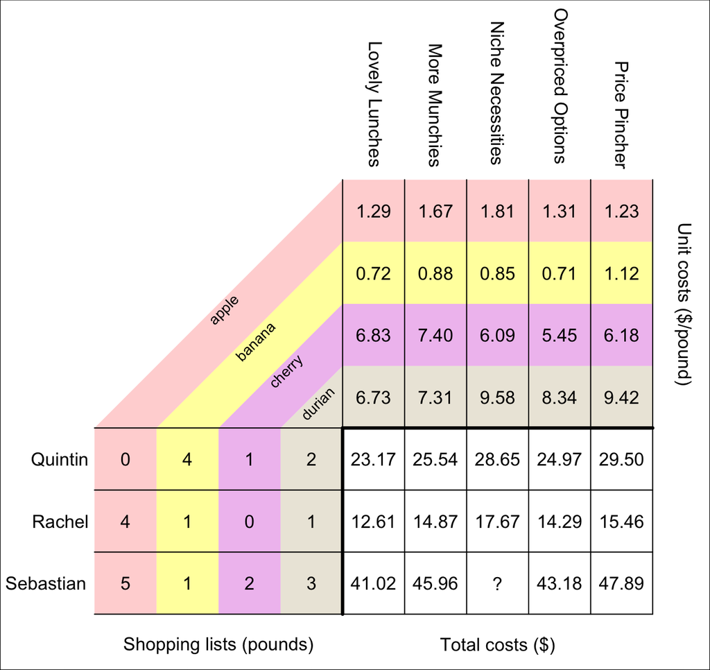

What is the total cost of Sebastian shopping at Niche Necessities?

Sebastian wishes to buy 5 lb of apple, 1 lb of banana, 2 lb of cherry, and 3 lb of durian. At Niche Necessities, the unit price of apple is $1.81/lb, the unit price of banana is $0.85/lb, the unit price of cherry is $6.09/lb, and the unit price of durian is $9.58/lb.

To find the total cost of Sebastian's shopping trip, multiply each quantity by its corresponding unit price and then add up all those products.

$$(5\cdot1.81)~+~(1\cdot0.85)~+~(2\cdot6.09)~+~(3\cdot9.58)$$
$$9.05~+~0.85~+~12.18~+~28.74$$
$$50.82$$

So, the total cost of Sebastian shopping at Niche Necessities is $50.82.

In standard math notation, the matrix multiplication would be shown as:

$$\begin{bmatrix}
0 & 4 & 1 & 2\\
4 & 1 & 0 & 1\\
5 & 1 & 2 & 3
\end{bmatrix} \cdot \begin{bmatrix}
1.29 & 1.67 & 1.81 & 1.31 & 1.23\\
0.72 & 0.88 & 0.85 & 0.71 & 1.12\\
6.83 & 7.4 & 6.09 & 5.45 & 6.18\\
6.73 & 7.31 & 9.58 & 8.34 & 9.42
\end{bmatrix} ~=~ \begin{bmatrix}
23.17 & 25.54 & 28.65 & 24.97 & 29.5\\
12.61 & 14.87 & 17.67 & 14.29 & 15.46\\
41.02 & 45.96 & 50.82 & 43.18 & 47.89
\end{bmatrix}$$

Three people are buying fruit, and there are five grocery stores. Each person has a shopping list dictating how many pounds of each fruit to buy. Each store has different unit costs of fruit.

In order to consider the **total** cost for each person at each store, we can use [matrix multiplication](https://en.wikipedia.org/wiki/Matrix_multiplication). In order to help visualize matrix multiplication, the shopping lists are shown as a matrix on the bottom-left, the unit prices as a matrix on top-right, and the resulting matrix of totals in the bottom-right.

A peculiarity of matrix multiplication requires the **columns** of the first matrix to "match" the **rows** of the second matrix. In this case, notice the various fruits correspond to columns in the first matrix (bottom-left) and rows in the second matrix (top-right). This visualization is an attempt to make this seem more natural.

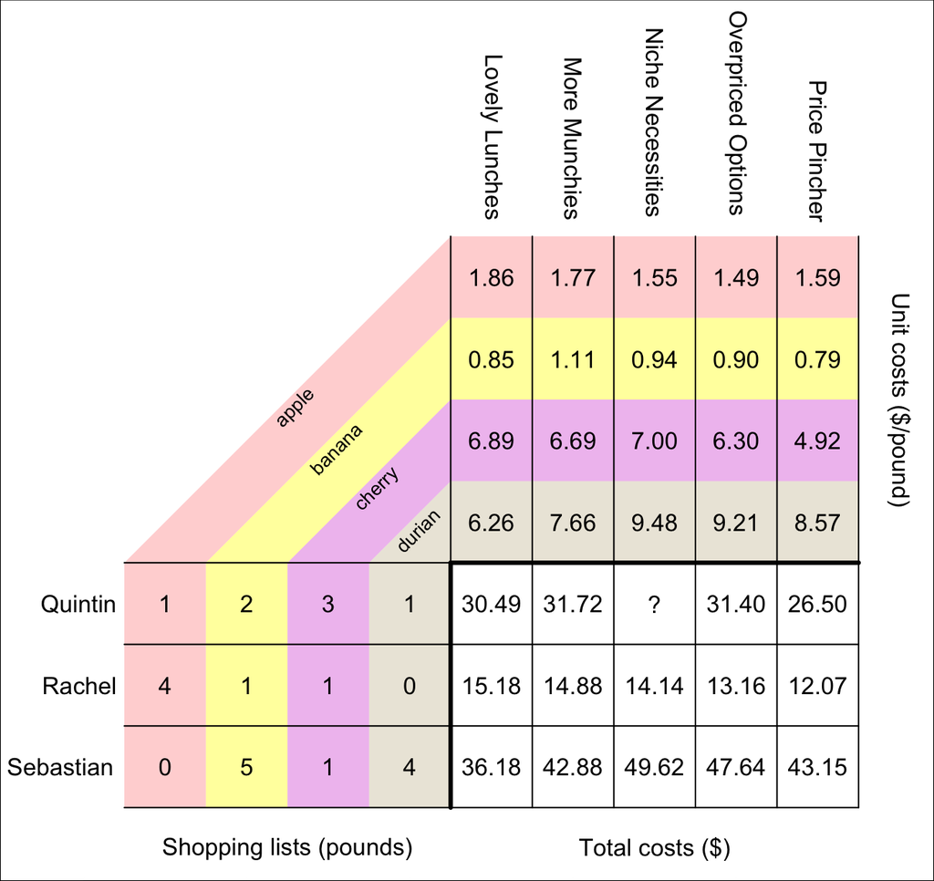

What is the total cost of Quintin shopping at Niche Necessities?

Quintin wishes to buy 1 lb of apple, 2 lb of banana, 3 lb of cherry, and 1 lb of durian. At Niche Necessities, the unit price of apple is $1.55/lb, the unit price of banana is $0.94/lb, the unit price of cherry is $7.00/lb, and the unit price of durian is $9.48/lb.

To find the total cost of Quintin's shopping trip, multiply each quantity by its corresponding unit price and then add up all those products.

$$(1\cdot1.55)~+~(2\cdot0.94)~+~(3\cdot7)~+~(1\cdot9.48)$$
$$1.55~+~1.88~+~21~+~9.48$$
$$33.91$$

So, the total cost of Quintin shopping at Niche Necessities is $33.91.

In standard math notation, the matrix multiplication would be shown as:

$$\begin{bmatrix}
1 & 2 & 3 & 1\\
4 & 1 & 1 & 0\\
0 & 5 & 1 & 4
\end{bmatrix} \cdot \begin{bmatrix}
1.86 & 1.77 & 1.55 & 1.49 & 1.59\\
0.85 & 1.11 & 0.94 & 0.9 & 0.79\\
6.89 & 6.69 & 7 & 6.3 & 4.92\\
6.26 & 7.66 & 9.48 & 9.21 & 8.57
\end{bmatrix} ~=~ \begin{bmatrix}
30.49 & 31.72 & 33.91 & 31.4 & 26.5\\
15.18 & 14.88 & 14.14 & 13.16 & 12.07\\
36.18 & 42.88 & 49.62 & 47.64 & 43.15
\end{bmatrix}$$

Three people are buying fruit, and there are five grocery stores. Each person has a shopping list dictating how many pounds of each fruit to buy. Each store has different unit costs of fruit.

In order to consider the **total** cost for each person at each store, we can use [matrix multiplication](https://en.wikipedia.org/wiki/Matrix_multiplication). In order to help visualize matrix multiplication, the shopping lists are shown as a matrix on the bottom-left, the unit prices as a matrix on top-right, and the resulting matrix of totals in the bottom-right.

A peculiarity of matrix multiplication requires the **columns** of the first matrix to "match" the **rows** of the second matrix. In this case, notice the various fruits correspond to columns in the first matrix (bottom-left) and rows in the second matrix (top-right). This visualization is an attempt to make this seem more natural.

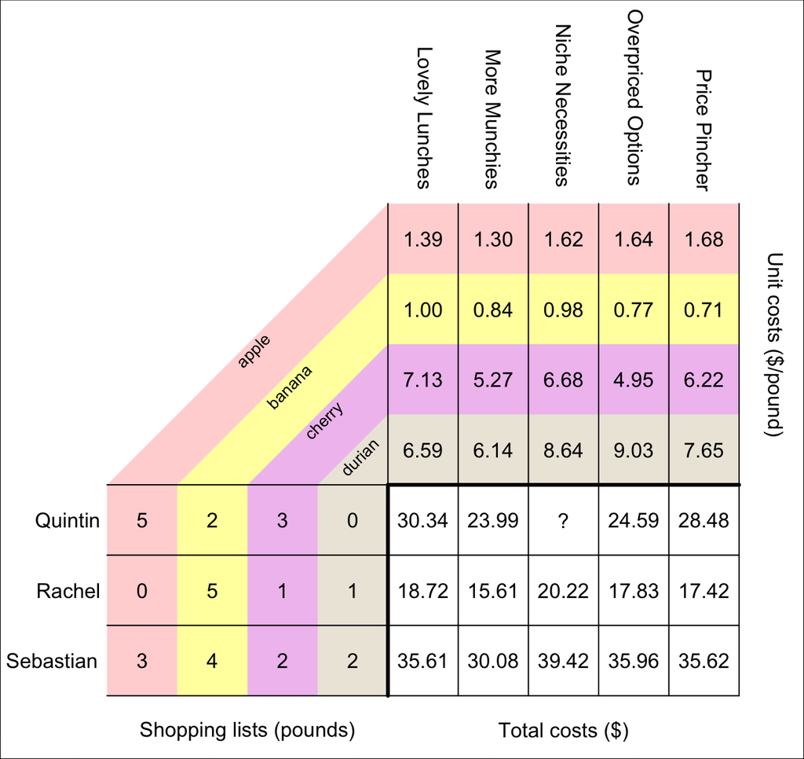

What is the total cost of Quintin shopping at Niche Necessities?

Quintin wishes to buy 5 lb of apple, 2 lb of banana, 3 lb of cherry, and 0 lb of durian. At Niche Necessities, the unit price of apple is $1.62/lb, the unit price of banana is $0.98/lb, the unit price of cherry is $6.68/lb, and the unit price of durian is $8.64/lb.

To find the total cost of Quintin's shopping trip, multiply each quantity by its corresponding unit price and then add up all those products.

$$(5\cdot1.62)~+~(2\cdot0.98)~+~(3\cdot6.68)~+~(0\cdot8.64)$$
$$8.1~+~1.96~+~20.04~+~0$$
$$30.10$$

So, the total cost of Quintin shopping at Niche Necessities is $30.10.

In standard math notation, the matrix multiplication would be shown as:

$$\begin{bmatrix}
5 & 2 & 3 & 0\\
0 & 5 & 1 & 1\\
3 & 4 & 2 & 2
\end{bmatrix} \cdot \begin{bmatrix}
1.39 & 1.3 & 1.62 & 1.64 & 1.68\\
1 & 0.84 & 0.98 & 0.77 & 0.71\\
7.13 & 5.27 & 6.68 & 4.95 & 6.22\\
6.59 & 6.14 & 8.64 & 9.03 & 7.65
\end{bmatrix} ~=~ \begin{bmatrix}
30.34 & 23.99 & 30.1 & 24.59 & 28.48\\
18.72 & 15.61 & 20.22 & 17.83 & 17.42\\
35.61 & 30.08 & 39.42 & 35.96 & 35.62
\end{bmatrix}$$

Three people are buying fruit, and there are five grocery stores. Each person has a shopping list dictating how many pounds of each fruit to buy. Each store has different unit costs of fruit.

In order to consider the **total** cost for each person at each store, we can use [matrix multiplication](https://en.wikipedia.org/wiki/Matrix_multiplication). In order to help visualize matrix multiplication, the shopping lists are shown as a matrix on the bottom-left, the unit prices as a matrix on top-right, and the resulting matrix of totals in the bottom-right.

A peculiarity of matrix multiplication requires the **columns** of the first matrix to "match" the **rows** of the second matrix. In this case, notice the various fruits correspond to columns in the first matrix (bottom-left) and rows in the second matrix (top-right). This visualization is an attempt to make this seem more natural.

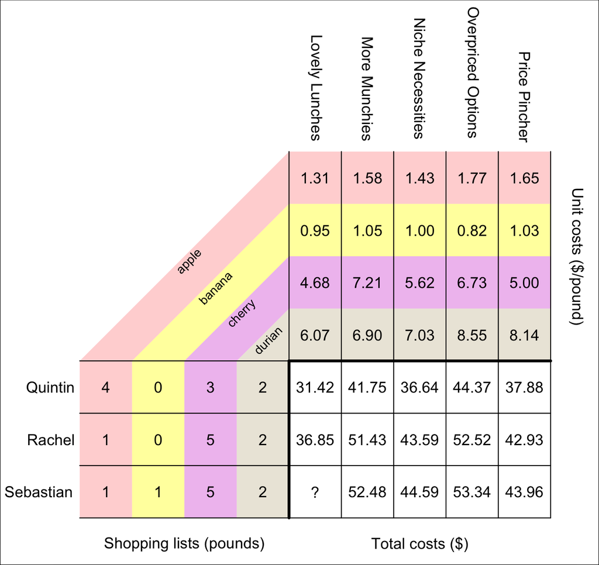

What is the total cost of Sebastian shopping at Lovely Lunches?

Sebastian wishes to buy 1 lb of apple, 1 lb of banana, 5 lb of cherry, and 2 lb of durian. At Lovely Lunches, the unit price of apple is $1.31/lb, the unit price of banana is $0.95/lb, the unit price of cherry is $4.68/lb, and the unit price of durian is $6.07/lb.

To find the total cost of Sebastian's shopping trip, multiply each quantity by its corresponding unit price and then add up all those products.

$$(1\cdot1.31)~+~(1\cdot0.95)~+~(5\cdot4.68)~+~(2\cdot6.07)$$
$$1.31~+~0.95~+~23.4~+~12.14$$
$$37.80$$

So, the total cost of Sebastian shopping at Lovely Lunches is $37.80.

In standard math notation, the matrix multiplication would be shown as:

$$\begin{bmatrix}
4 & 0 & 3 & 2\\
1 & 0 & 5 & 2\\
1 & 1 & 5 & 2
\end{bmatrix} \cdot \begin{bmatrix}
1.31 & 1.58 & 1.43 & 1.77 & 1.65\\
0.95 & 1.05 & 1 & 0.82 & 1.03\\
4.68 & 7.21 & 5.62 & 6.73 & 5\\
6.07 & 6.9 & 7.03 & 8.55 & 8.14
\end{bmatrix} ~=~ \begin{bmatrix}
31.42 & 41.75 & 36.64 & 44.37 & 37.88\\
36.85 & 51.43 & 43.59 & 52.52 & 42.93\\
37.8 & 52.48 & 44.59 & 53.34 & 43.96
\end{bmatrix}$$

Three people are buying fruit, and there are five grocery stores. Each person has a shopping list dictating how many pounds of each fruit to buy. Each store has different unit costs of fruit.

In order to consider the **total** cost for each person at each store, we can use [matrix multiplication](https://en.wikipedia.org/wiki/Matrix_multiplication). In order to help visualize matrix multiplication, the shopping lists are shown as a matrix on the bottom-left, the unit prices as a matrix on top-right, and the resulting matrix of totals in the bottom-right.

A peculiarity of matrix multiplication requires the **columns** of the first matrix to "match" the **rows** of the second matrix. In this case, notice the various fruits correspond to columns in the first matrix (bottom-left) and rows in the second matrix (top-right). This visualization is an attempt to make this seem more natural.

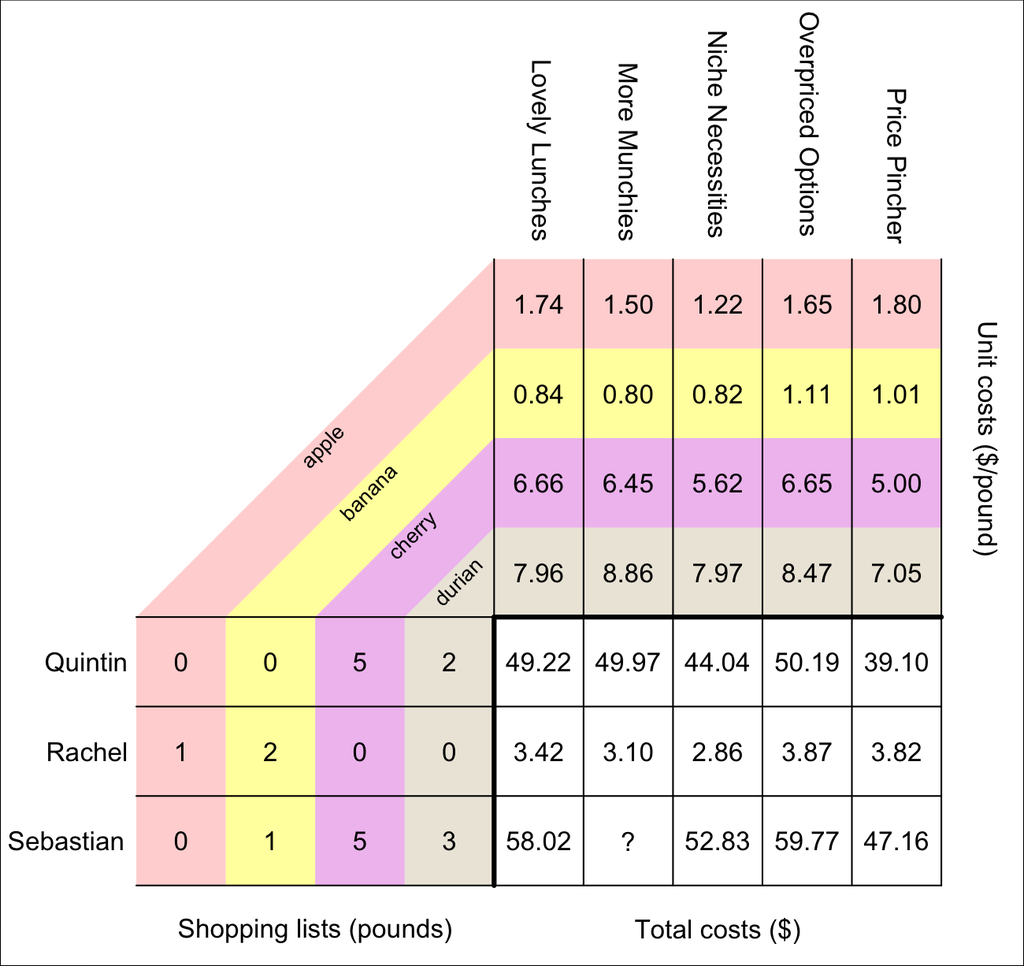

What is the total cost of Sebastian shopping at More Munchies?

Sebastian wishes to buy 0 lb of apple, 1 lb of banana, 5 lb of cherry, and 3 lb of durian. At More Munchies, the unit price of apple is $1.50/lb, the unit price of banana is $0.80/lb, the unit price of cherry is $6.45/lb, and the unit price of durian is $8.86/lb.

To find the total cost of Sebastian's shopping trip, multiply each quantity by its corresponding unit price and then add up all those products.

$$(0\cdot1.5)~+~(1\cdot0.8)~+~(5\cdot6.45)~+~(3\cdot8.86)$$
$$0~+~0.8~+~32.25~+~26.58$$
$$59.63$$

So, the total cost of Sebastian shopping at More Munchies is $59.63.

In standard math notation, the matrix multiplication would be shown as:

$$\begin{bmatrix}
0 & 0 & 5 & 2\\
1 & 2 & 0 & 0\\
0 & 1 & 5 & 3
\end{bmatrix} \cdot \begin{bmatrix}
1.74 & 1.5 & 1.22 & 1.65 & 1.8\\
0.84 & 0.8 & 0.82 & 1.11 & 1.01\\
6.66 & 6.45 & 5.62 & 6.65 & 5\\
7.96 & 8.86 & 7.97 & 8.47 & 7.05
\end{bmatrix} ~=~ \begin{bmatrix}
49.22 & 49.97 & 44.04 & 50.19 & 39.1\\
3.42 & 3.1 & 2.86 & 3.87 & 3.82\\
58.02 & 59.63 & 52.83 & 59.77 & 47.16
\end{bmatrix}$$

Three people are buying fruit, and there are five grocery stores. Each person has a shopping list dictating how many pounds of each fruit to buy. Each store has different unit costs of fruit.

In order to consider the **total** cost for each person at each store, we can use [matrix multiplication](https://en.wikipedia.org/wiki/Matrix_multiplication). In order to help visualize matrix multiplication, the shopping lists are shown as a matrix on the bottom-left, the unit prices as a matrix on top-right, and the resulting matrix of totals in the bottom-right.

A peculiarity of matrix multiplication requires the **columns** of the first matrix to "match" the **rows** of the second matrix. In this case, notice the various fruits correspond to columns in the first matrix (bottom-left) and rows in the second matrix (top-right). This visualization is an attempt to make this seem more natural.

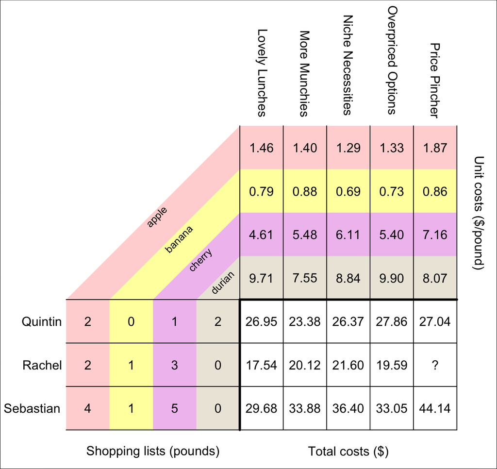

What is the total cost of Rachel shopping at Price Pincher?

Rachel wishes to buy 2 lb of apple, 1 lb of banana, 3 lb of cherry, and 0 lb of durian. At Price Pincher, the unit price of apple is $1.87/lb, the unit price of banana is $0.86/lb, the unit price of cherry is $7.16/lb, and the unit price of durian is $8.07/lb.

To find the total cost of Rachel's shopping trip, multiply each quantity by its corresponding unit price and then add up all those products.

$$(2\cdot1.87)~+~(1\cdot0.86)~+~(3\cdot7.16)~+~(0\cdot8.07)$$
$$3.74~+~0.86~+~21.48~+~0$$
$$26.08$$

So, the total cost of Rachel shopping at Price Pincher is $26.08.

In standard math notation, the matrix multiplication would be shown as:

$$\begin{bmatrix}
2 & 0 & 1 & 2\\
2 & 1 & 3 & 0\\
4 & 1 & 5 & 0
\end{bmatrix} \cdot \begin{bmatrix}
1.46 & 1.4 & 1.29 & 1.33 & 1.87\\
0.79 & 0.88 & 0.69 & 0.73 & 0.86\\
4.61 & 5.48 & 6.11 & 5.4 & 7.16\\
9.71 & 7.55 & 8.84 & 9.9 & 8.07
\end{bmatrix} ~=~ \begin{bmatrix}
26.95 & 23.38 & 26.37 & 27.86 & 27.04\\
17.54 & 20.12 & 21.6 & 19.59 & 26.08\\
29.68 & 33.88 & 36.4 & 33.05 & 44.14
\end{bmatrix}$$

Three people are buying fruit, and there are five grocery stores. Each person has a shopping list dictating how many pounds of each fruit to buy. Each store has different unit costs of fruit.

In order to consider the **total** cost for each person at each store, we can use [matrix multiplication](https://en.wikipedia.org/wiki/Matrix_multiplication). In order to help visualize matrix multiplication, the shopping lists are shown as a matrix on the bottom-left, the unit prices as a matrix on top-right, and the resulting matrix of totals in the bottom-right.

A peculiarity of matrix multiplication requires the **columns** of the first matrix to "match" the **rows** of the second matrix. In this case, notice the various fruits correspond to columns in the first matrix (bottom-left) and rows in the second matrix (top-right). This visualization is an attempt to make this seem more natural.

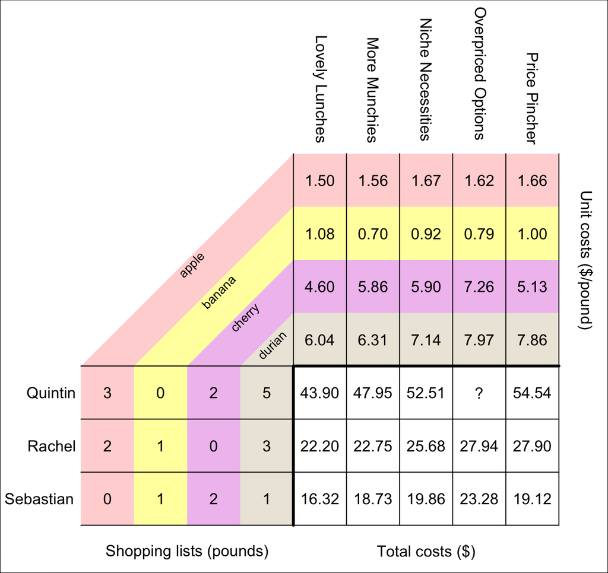

What is the total cost of Quintin shopping at Overpriced Options?

Quintin wishes to buy 3 lb of apple, 0 lb of banana, 2 lb of cherry, and 5 lb of durian. At Overpriced Options, the unit price of apple is $1.62/lb, the unit price of banana is $0.79/lb, the unit price of cherry is $7.26/lb, and the unit price of durian is $7.97/lb.